# Likelihood Inference for Non-Linear Multivariate Jump Diffusions with State Dependent Intensity

Example replication materials

Etienne A.D. Pienaar

February, 2016

# Readme

This file provides replication materials for examples and analysis conducted in the paper “Likelihood Inference for Non-Linear Multivariate Jump Diffusions with State Dependent Intensity”, which develops the methodology on which the **DiffusionRjgqd** package is built. As such, this file may not be useful as a stand-alone document, and should be read in conjunction with the paper. Note further:

- For users that find the interface difficult to understand it may be useful to read material on the ralated package: [**DiffusionRgqd**](https://cran.r-project.org/package=DiffusionRgqd) and the introductory vignettes therein.
- In order to save time and keep this document readable, we reffrain from producing output for some of the examples.
- Some of the examples provided here are given in greater detail within the package vignettes (start here, or skip to the further reading section).

# Approximating the transitional density of a jump diffusion

## A scalar example (Section 3.3)

```r
library(DiffusionRjgqd)

# Define the jump diffusion in DiffusionRjgqd syntax:
JGQD.remove()
```

```
## [1] "Removed :  NA "
```

```r
G0=function(t){2*5}
G1=function(t){-2}
Q1=function(t){1*(1+0.4*sin(pi*t))^2}

# Set the transition rates and state values for CTMC:
lambda_1 = 1
lambda_2 = 3
beta_1 = 0.25
beta_2 = 1

Jmu    = function(t){1}
Jsig   = function(t){0.25}
Lam0 = function(t){lambda_1*(beta_2+beta_1*exp(-(beta_1+beta_2)*t))/(beta_1+beta_2)+lambda_2*beta_1/(beta_1+beta_2)*(1-exp(-(beta_1+beta_2)*t))}


# Define the jump diffusion coefficients for simulation:
mu     = function(x,t){G0(t)+G1(t)*x}
sigma  = function(x,t){sqrt(Q1(t)*x)}
j      = function(x,z){z}
simulate=function(x0=4,N=10000,pts =c(1,2,3,4,5),init.state=1)
{
  d     = 0               # Time index
  delta = 1/1000          # Step size
  tt    = seq(0,5,delta)  # Equispaced time points
  X     = rep(x0,N)       # Initialize state vector
  states= rep(c(lambda_1,lambda_2)[init.state],N)       # Initialize intensity process

  # Storage for record of the evolution of the moments:
  moments     = matrix(0,4,length(tt))
  cumulants   = moments
  moments[,1] = x0^{1:4}
  cumulants[1,1] = x0

  # Storage of snapshots of the simulated trajectories:
  L     = list()
  count =1

  for(i in 2:length(tt))
  {
     X=X+mu(X,d)*delta+sigma(X,d)*rnorm(N,sd=sqrt(delta))
    # Simulate the occurance of a jump event:
    events = (1-exp(-Lam0(d)*delta)>runif(N))
    wh=which(events)
    # For those trajectories that events do occur, simulate a jumps
    # half a step forward:
    if(any(events))
    {
      X[wh]=X[wh]+j(X[wh],rnorm(length(wh),Jmu(d),Jsig(d)))
    }
    d=d+delta

    # Calculate the prob of a change for a given state:
    probs1=beta_1/(beta_1+beta_2)*(1-exp(-(beta_1+beta_2)*delta))
    probs2=beta_2/(beta_1+beta_2)*(1-exp(-(beta_1+beta_2)*delta))

    # For a given state, simulate transitions (or remain in a given state):
    which1=which(states==lambda_1)
    which2=which(states==lambda_2)
    if(length(which1)!=0)
    {
       whh1.2=which(runif(length(which1))<probs1)
       if(length(whh1.2)!=0)
       {
        states[which1][whh1.2]=lambda_2
       }
    }
    if(length(which2)!=0)
    {
      whh2.2=which(runif(length(which2))<probs2)
      if(length(whh2.2)!=0)
      {
       states[which2][whh2.2]=lambda_1
      }
    }

    # Record the moments of the process:
    S1=sum(X);S2=sum(X^2);S3=sum(X^3);S4=sum(X^4)

    moments[,i]=c(S1,S2,S3,S4)/N
    cumulants[1,i] = S1/N
    cumulants[2,i] = 1/(N*(N-1))*(N*S2-S1^2)
    cumulants[3,i] = 1/(N*(N-1)*(N-2))*(2*S1^3-3*N*S1*S2+N^2*S3)
    cumulants[4,i] = (1/(N*(N-1)*(N-2)*(N-3))*(-6*S1^4+12*N*S1^2*S2-3*N*(N-1)*S2^2
                      -4*N*(N+1)*S1*S3+N^2*(N+1)*S4))
    # Take snapshots at pts[count]:
    if(sum(pts==round(d,3))!=0)
    {
       L[[count]] = hist(X,plot=F,breaks=25)
       count=count+1
    }
  }
  return(list(moments=moments,cumulants=cumulants,time=tt,hists=L,pts=pts))
}
 # Simulate the process:
 res.sim=simulate()
 # Calculate the approximate transition density:
 res = JGQD.density(4,seq(2,14,1/10),0,5,1/100)
```

```
##
##  ================================================================
##             Jump Generalized Quadratic Diffusion (JGQD)
##  ================================================================
##  _____________________ Drift Coefficients _______________________
##  G0 : 2*5
##  G1 : -2
##  G2
##  ___________________ Diffusion Coefficients _____________________
##  Q0
##  Q1 : 1*(1+0.4*sin(pi*t))^2
##  Q2
##  _______________________ Jump Mechanism _________________________
##  ......................... Intensity ............................
##  Lam0 : lambda_1*(beta_2+beta_1*exp(-(beta_1+beta_2)*t))/(beta_1+beta_2)+lambda_2*beta_1/(beta_1+beta_2)*(1-exp(-(beta_1+beta_2)*t))
##  Lam1
##  Lam2
##  ........................... Jumps ..............................
##  Normal
##  Jmu : 1
##  Jsig : 0.25
##  __________________ Distribution Approximant ____________________
##  Density approx. : Saddlepoint
##  Trunc. Order    : 8
##  Dens.  Order    : 4
## =================================================================
```

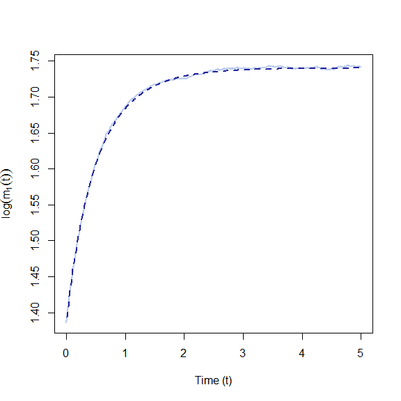

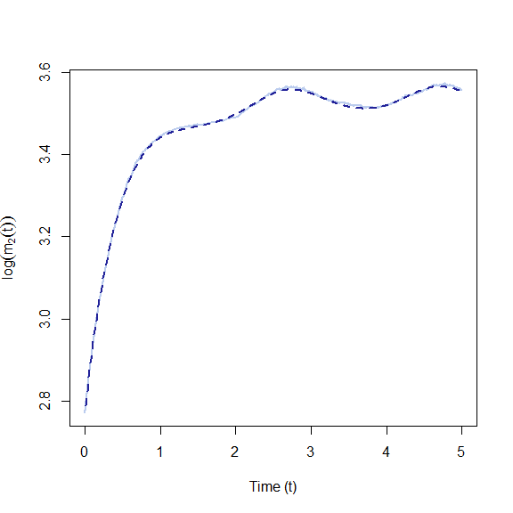

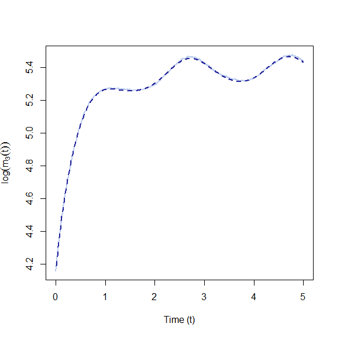

```r
 # Compare moments:
 exprs =c(expression(log(m[1](t))),expression(log(m[2](t))),expression(log(m[3](t)))
          ,expression(log(m[4](t))))
 par(mfrow=c(1,1))
 for(i in 1:4)
 {
  plot(log(res.sim$moments[i,])~res.sim$time,type='l',ylab = exprs[i],xlab='Time (t)'
       ,lwd=2,col="#BBCCEE")
  lines(log(res$moments[i,])~res$time,lty='dashed',col='#222299',lwd=2)
 }
```

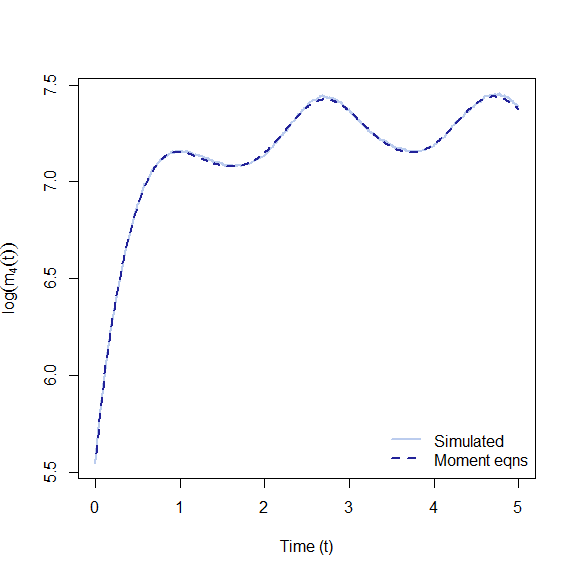

```r
 legend('bottomright',lty=c('solid','dashed'),col=c('#BBCCEE','#222299'),
        legend=c('Simulated','Moment eqns'),lwd=2,bty='n')
```

```r
  library(rgl)
   um  = rbind(
  c(-0.7762160,  0.6299503, 0.02552053,    0),
  c(-0.2308982, -0.3217098, 0.91825324,    0),
  c(0.5866640,  0.7068703, 0.39517075,    0),
  c(0.0000000,  0.0000000, 0.00000000,    1))

  r3dDefaults$userMatrix =um
  open3d(windowRect=c(0,0,360*1.5,360*1.5)+30,zoom=6/8)
```

```
## wgl
##   1
```

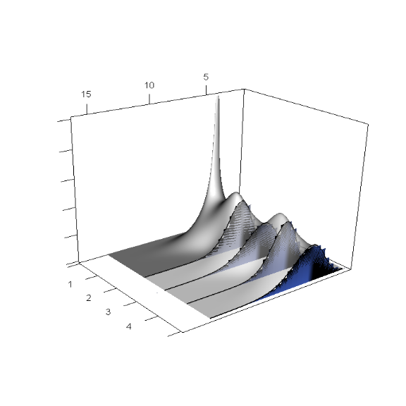

```r
  persp3d(res$Xt,res$time,pmax(pmin(res$density,1),0),col='white',alpha=0.5,box=F,
          xlab='Xt',ylab='Time',zlab='')
  surface3d(res$Xt,res$time[-c(1,201:501)],pmax(pmin(res$density[,2:200],1),0),col='white')
  cols=colorRampPalette(c("red", "yellow"))
  library(colorspace)
  colpal=function(n){rev(sequential_hcl(n,power=0.8,l=c(40,100)))}

  for(i in 2:5)
  {
    h1 =res.sim$hists[[i]]
    y=rep(h1$density,each=2)
    x=c(rbind(h1$breaks[-length(h1$breaks)],h1$breaks[-1]))
    hd=cbind(0,y,0)
    tt=res.sim$pts[i]
    surface3d(x,c(tt-0.0001,tt,tt+0.0001),hd,col=colpal(5)[i],alpha=1)
    lines3d(res$Xt,tt,res$density[,i*100],col='black',lwd=2)
  }


  rgl.snapshot('temp.png')
  library(png)
  imag = readPNG(paste0(getwd(),'/temp.png'))
  par(mfrow=c(1,1))
  plot(1:2, type='n', main="", xlab="", ylab="",axes=FALSE)
  lim <- par()
  rasterImage(imag, lim$usr[1], lim$usr[3], lim$usr[2], lim$usr[4])
```

```r
  # Generate a comparison for starting in the high intensity regime
  Lam0 = function(t){lambda_1*beta_2/(beta_1+beta_2)*(1-exp(-(beta_1+beta_2)*t))+lambda_2*(beta_2+beta_1*exp(-(beta_1+beta_2)*t))/(beta_1+beta_2)}
  # Simulate the process:
  res2.sim=simulate(init.state=2)
  # Calculate the approximate transition density:
  res2 = JGQD.density(4,seq(2,14,1/10),0,5,1/100)
```

```
##
##  ================================================================
##             Jump Generalized Quadratic Diffusion (JGQD)
##  ================================================================
##  _____________________ Drift Coefficients _______________________
##  G0 : 2*5
##  G1 : -2
##  G2
##  ___________________ Diffusion Coefficients _____________________
##  Q0
##  Q1 : 1*(1+0.4*sin(pi*t))^2
##  Q2
##  _______________________ Jump Mechanism _________________________
##  ......................... Intensity ............................
##  Lam0 : lambda_1*beta_2/(beta_1+beta_2)*(1-exp(-(beta_1+beta_2)*t))+lambda_2*(beta_2+beta_1*exp(-(beta_1+beta_2)*t))/(beta_1+beta_2)
##  Lam1
##  Lam2
##  ........................... Jumps ..............................
##  Normal
##  Jmu : 1
##  Jsig : 0.25
##  __________________ Distribution Approximant ____________________
##  Density approx. : Saddlepoint
##  Trunc. Order    : 8
##  Dens.  Order    : 4
## =================================================================
```

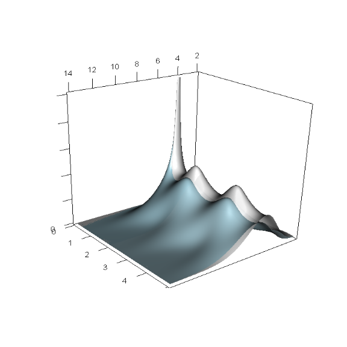

```r
  persp3d(res$Xt,res$time,pmax(pmin(res$density,1),0),col='white',alpha=0.9,box=F,
          xlab='Xt',ylab='Time',zlab='')
  surface3d(res$Xt,res$time[-c(1,201:501)],pmax(pmin(res$density[,2:200],1),0),col='white')
  surface3d(res2$Xt,res2$time,pmax(pmin(res2$density,1),0),col='lightblue',alpha=0.9)
  surface3d(res2$Xt,res2$time[-c(1,201:501)],pmax(pmin(res2$density[,2:200],1),0),col='lightblue')

  rgl.snapshot('temp.png')
  library(png)
  imag = readPNG(paste0(getwd(),'/temp.png'))
  plot(1:2, type='n', main="", xlab="", ylab="",axes=FALSE)
  lim <- par()
  rasterImage(imag, lim$usr[1], lim$usr[3], lim$usr[2], lim$usr[4])
```

## Short time-scale dynamics and the excess factorization (Section 3.4)

```r
 library(DiffusionRjgqd)
# Define the process in DiffusionRjgqd syntax:
JGQD.remove()
```

```
## [1] "Removed :  G0 G1 Q1 Lam0 Jmu Jsig"
```

```r
G0=function(t){2*5}
G1=function(t){-2}
Q1=function(t){0.25}
Jmu    = function(t){1.0}
Jsig   = function(t){0.5}
Lam0    = function(t){0}
Lam1    = function(t){0.5*(1+sin(3*pi*t))}
Lam2    = function(t){0.1*(1+cos(3*pi*t))}

# Define the jump diffusion coefficients for simulation:
mu     = function(x,t){G0(t)+G1(t)*x}
sigma  = function(x,t){sqrt(Q1(t)*x)}
j      = function(x,z){z}
lambd  = function(x,t){(Lam0(t)+Lam1(t)*x+Lam2(t)*x^2)}

simulate=function(x0=4,TT=1.15,N=50000,pts =c(1,2,3,4,5),brks=25)
{
  d=0                # Time index
  delta=1/2000       # Step size
  tt=seq(0,TT,delta) # Equispaced points on [0,TT]
  X=rep(x0,N)        # Initialize the state vector

  isjump = rep(0,N)  # Used for counting the number of jumps

  probs=matrix(1,3,length(tt))  # Used to store probabilities

  # Storage of snapshots of the simulated trajectories:
  L     = list()
  count =1

  for(i in 2:length(tt))
  {
    # Simulate the diffuse part:
    X=X+mu(X,d)*delta+sigma(X,d)*rnorm(N,sd=sqrt(delta))
    # Simulate the occurance of a jump event:
    events = (1-exp(-lambd(X,d)*delta)>runif(N))
    wh=which(events)
    whn = which(!events)

    # For those trajectories that events do occur, simulate a jumps:
    if(any(events))
    {
      X[wh]=X[wh]+j(X[wh],rnorm(length(wh),Jmu(d),Jsig(d)))
    }
    d=d+delta

    isjump = isjump +events

    probs[1,i] = sum(isjump==0)/N
    probs[2,i] = sum(isjump==1)/N
    probs[3,i] = sum(isjump==2)/N

    # Take snapshots at pts[count]:
    if(sum(pts==round(d,4))!=0)
    {
       L[[count]] = hist(X,plot=F,breaks=brks)
       count=count+1
    }
  }
  return(list(probs=probs,time =tt,X=X,hists=L,pts=pts))
}
 res2a=simulate()

 resa=JGQD.density(Xs=4,Xt=seq(0,20,1/10),s=0,t=1.15,delt=1/100)
```

```
##
##  ================================================================
##             Jump Generalized Quadratic Diffusion (JGQD)
##  ================================================================
##  _____________________ Drift Coefficients _______________________
##  G0 : 2*5
##  G1 : -2
##  G2
##  ___________________ Diffusion Coefficients _____________________
##  Q0
##  Q1 : 0.25
##  Q2
##  _______________________ Jump Mechanism _________________________
##  ......................... Intensity ............................
##  Lam0 : 0
##  Lam1 : 0.5*(1+sin(3*pi*t))
##  Lam2 : 0.1*(1+cos(3*pi*t))
##  ........................... Jumps ..............................
##  Normal
##  Jmu : 1
##  Jsig : 0.5
##  __________________ Distribution Approximant ____________________
##  Density approx. : Saddlepoint
##  Trunc. Order    : 8
##  Dens.  Order    : 4
## =================================================================
```

```r
 Lam1=function(t){0.2}
 Lam2=function(t){0}
 res2b=simulate()
 resb=JGQD.density(Xs=4,Xt=seq(0,20,1/10),s=0,t=1.15,delt=1/100)
```

```
##
##  ================================================================
##             Jump Generalized Quadratic Diffusion (JGQD)
##  ================================================================
##  _____________________ Drift Coefficients _______________________
##  G0 : 2*5
##  G1 : -2
##  G2
##  ___________________ Diffusion Coefficients _____________________
##  Q0
##  Q1 : 0.25
##  Q2
##  _______________________ Jump Mechanism _________________________
##  ......................... Intensity ............................
##  Lam0 : 0
##  Lam1 : 0.2
##  Lam2 : 0
##  ........................... Jumps ..............................
##  Normal
##  Jmu : 1
##  Jsig : 0.5
##  __________________ Distribution Approximant ____________________
##  Density approx. : Saddlepoint
##  Trunc. Order    : 8
##  Dens.  Order    : 4
## =================================================================
```

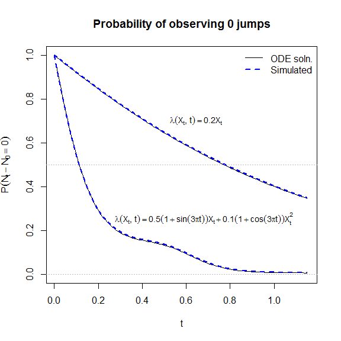

```r
 pp1 = resa$zero_jump_prob
 pp2 = resb$zero_jump_prob
 epr1 = expression(X[t])
 epr2 = expression(d/dt*log(P(N[t]-N[s]==0))==E[X](lambda(X[t],t)))
 # Plot the evolution of the 0 jump probabilities
 plot(pp1~resa$time,type='l',ylim=c(0,1),lwd=1,col='black',
      main='Probability of observing 0 jumps',ylab=expression(P(N[t]-N[0] == 0)),
      xlab='t')#,axes=F)
 lines(res2a$probs[1,]~res2a$time,col='blue',lty='dashed',lwd=2)
 lines(pp2~resa$time,col='black',lty='solid',lwd=1)
 lines(res2b$probs[1,]~res2b$time,col='blue',lty='dashed',lwd=2)
 abline(h=c(0.0,0.5,0.5),lty='dotted',col='grey')
 legend('topright',lty=c('solid','dashed'),lwd=c(1,2),col=c('black','blue'),
        legend=c('ODE soln.','Simulated'),bty='n')
 text(0.5,0.7,label=expression(lambda(X[t],t) == 0.2*X[t]),pos=4,cex=0.85)
 text(0.25,0.25,label=expression(lambda(X[t],t) ==
      0.5*(1+sin(3*pi*t))*X[t]+0.1*(1+cos(3*pi*t))*X[t]^2),pos=4,cex=0.85)
```

```r
  # Evaluate the transition densities over short transition horizons:
 TT=0.02
 Lam1    = function(t){0.5*(1+sin(3*pi*t))}
 Lam2    = function(t){0.1*(1+cos(3*pi*t))}
 res2a=simulate(TT=TT,pts=seq(0.5*TT,TT,length=4))
 resa=JGQD.density(Xs=4,Xt=seq(0,10,1/100),s=0,t=TT,delt=1/200,factorize=TRUE)
```

```
##
##  ================================================================
##             Jump Generalized Quadratic Diffusion (JGQD)
##  ================================================================
##  _____________________ Drift Coefficients _______________________
##  G0 : 2*5
##  G1 : -2
##  G2
##  ___________________ Diffusion Coefficients _____________________
##  Q0
##  Q1 : 0.25
##  Q2
##  _______________________ Jump Mechanism _________________________
##  ......................... Intensity ............................
##  Lam0 : 0
##  Lam1 : 0.5*(1+sin(3*pi*t))
##  Lam2 : 0.1*(1+cos(3*pi*t))
##  ........................... Jumps ..............................
##  Normal
##  Jmu : 1
##  Jsig : 0.5
##  __________________ Distribution Approximant ____________________
##  Density approx. : Saddlepoint
##  Trunc. Order    : 8
##  Dens.  Order    : 4
## =================================================================
```

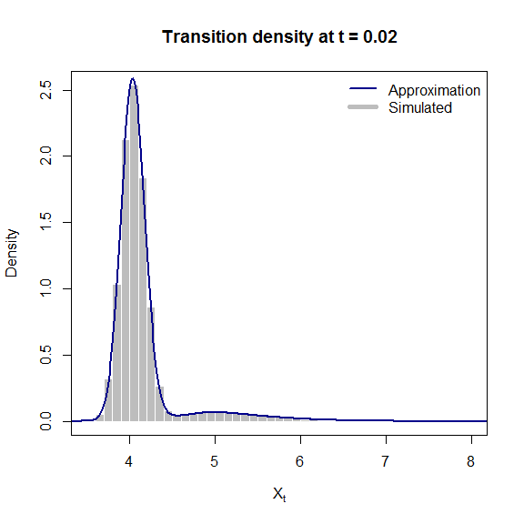

```r
 hist(res2a$X,freq=F,col='gray74',breaks=50,main=paste0('Transition density at t = ',
      TT),xlab=epr1,xlim=c(3.5,8),border='white')
 lines(resa$density[,TT*200]~resa$Xt,col='darkblue',lwd=2)
 legend('topright',lty=c('solid','solid'),lwd=c(2,5),col=c('darkblue','gray74'),
 legend=c('Approximation','Simulated'),bty='n')
 box()
```

```r
  TT=0.1
 Lam1=function(t){0.2}
 Lam2=function(t){0}
 res2b=simulate(TT=TT)
 resb=JGQD.density(Xs=4,Xt=seq(0,10,1/50),s=0,t=TT,delt=1/100,factorize=TRUE)
```

```
##
##  ================================================================
##             Jump Generalized Quadratic Diffusion (JGQD)
##  ================================================================
##  _____________________ Drift Coefficients _______________________
##  G0 : 2*5
##  G1 : -2
##  G2
##  ___________________ Diffusion Coefficients _____________________
##  Q0
##  Q1 : 0.25
##  Q2
##  _______________________ Jump Mechanism _________________________
##  ......................... Intensity ............................
##  Lam0 : 0
##  Lam1 : 0.2
##  Lam2 : 0
##  ........................... Jumps ..............................
##  Normal
##  Jmu : 1
##  Jsig : 0.5
##  __________________ Distribution Approximant ____________________
##  Density approx. : Saddlepoint
##  Trunc. Order    : 8
##  Dens.  Order    : 4
## =================================================================
```

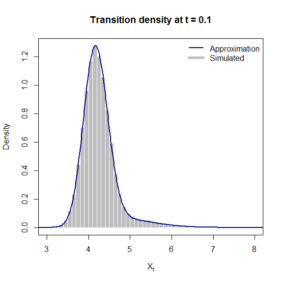

```r
 hist(res2b$X,freq=F,col='gray74',breaks=50,main=paste0('Transition density at t = ',
      TT),xlab=epr1,xlim=c(3,8),border='white')
 lines(resb$density[,TT*100]~resb$Xt,col='darkblue',lwd=2)
 legend('topright',lty=c('solid','solid'),lwd=c(2,5),col=c('darkblue','gray74'),
 legend=c('Approximation','Simulated'),bty='n')
 box()
```

```r
 TT=0.1
 Lam1=function(t){0.2}
 Lam2=function(t){0}
 Q1 =function(t){0.25}
 Jsig   = function(t){0.05}
 res.sim=simulate(TT=TT,pts=seq(0.04,0.1,length=3),brks=55)
 res    =JGQD.density(Xs=4,Xt=seq(3,7,1/50),s=0,t=TT,delt=1/200,factorize=TRUE)
```

```
##
##  ================================================================
##             Jump Generalized Quadratic Diffusion (JGQD)
##  ================================================================
##  _____________________ Drift Coefficients _______________________
##  G0 : 2*5
##  G1 : -2
##  G2
##  ___________________ Diffusion Coefficients _____________________
##  Q0
##  Q1 : 0.25
##  Q2
##  _______________________ Jump Mechanism _________________________
##  ......................... Intensity ............................
##  Lam0 : 0
##  Lam1 : 0.2
##  Lam2 : 0
##  ........................... Jumps ..............................
##  Normal
##  Jmu : 1
##  Jsig : 0.05
##  __________________ Distribution Approximant ____________________
##  Density approx. : Saddlepoint
##  Trunc. Order    : 8
##  Dens.  Order    : 4
## =================================================================
```

```r
  library(rgl)
    um  = rbind(
  c(-0.7762160,  0.6299503, 0.02552053,    0),
  c(-0.2308982, -0.3217098, 0.91825324,    0),
  c(0.5866640,  0.7068703, 0.39517075,    0),
  c(0.0000000,  0.0000000, 0.00000000,    1))

  r3dDefaults$userMatrix =um
  open3d(windowRect=c(0,0,360*1.5,360*1.5)+30,zoom=6/8)
```

```
## wgl
##   2
```

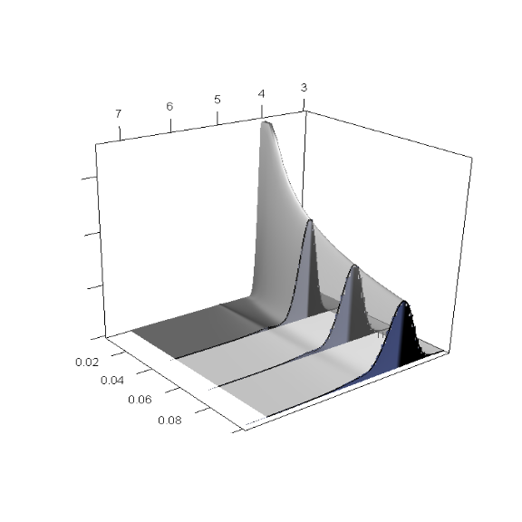

```r
  persp3d(res$Xt,res$time,pmax(pmin(res$density,3.5),0),col='white',alpha=0.4,box=F,
          xlab='Xt',ylab='Time',zlab='')
  surface3d(res$Xt,res$time[1:8],pmax(pmin(res$density[,1:8],3.5),0),col='white')
  cols=colorRampPalette(c("red", "yellow"))
  library(colorspace)
  colpal=function(n){rev(sequential_hcl(n,power=0.8,l=c(40,100)))}
  for(i in 1:length(res.sim$pts))
  {
    h1 =res.sim$hists[[i]]
    y=rep(h1$density,each=2)
    x=c(rbind(h1$breaks[-length(h1$breaks)],h1$breaks[-1]))
    hd=cbind(0,y,0)
    tt=res.sim$pts[i]
    surface3d(x,c(tt-0.0001,tt,tt+0.0001),hd,col=colpal(5)[i+1],alpha=1)
    lines3d(res$Xt,tt,res$density[,tt*200],col='black',lwd=2)
  }
  rgl.snapshot('temp.png')
  library(png)
  imag = readPNG(paste0(getwd(),'/temp.png'))
  par(mfrow=c(1,1))
  plot(1:2, type='n', main="", xlab="", ylab="",axes=FALSE)
  lim <- par()
  rasterImage(imag, lim$usr[1], lim$usr[3], lim$usr[2], lim$usr[4])
```

See also:

- Bivariate diffusions

```r
  JGQD.remove()
```

```
## [1] "Removed :  G0 G1 Q1 Lam0 Lam1 Lam2 Jmu Jsig"
```

```r
 theta=c(0.5,5,-0.1,0.4,0.4,6,-0.1,0.3,1,0.75,0.75,0.75,0.75)
 a00 = function(t){theta[1]*theta[2]}
 a10 = function(t){-theta[1]}
 a01 = function(t){theta[3]}
 c10 = function(t){theta[4]^2}

 b00 = function(t){theta[5]*theta[6]}
 b01 = function(t){-theta[5]}
 b10 = function(t){theta[7]}
 f01 = function(t){theta[8]^2}

 Lam00= function(t){theta[9]}

 Jmu1=function(t){theta[10]*(1+sin(2*pi*t))}
 Jmu2=function(t){theta[11]*(1+sin(2*pi*t))}
 Jsig11=function(t){theta[12]^2*(1+0.8*sin(2*pi*t))^2}
 Jsig22=function(t){theta[13]^2*(1+0.8*sin(2*pi*t))^2}

 xx=seq(3,11,1/10)
 yy=seq(3,11,1/10)
 res= BiJGQD.density(7,7,xx,yy,0,1,1/100,Dtype='Saddlepoint')
```

```
##
##  ================================================================
##                    GENERALIZED QUADRATIC DIFFUSON
##  ================================================================
##  _____________________ Drift Coefficients _______________________
##  a00 : theta[1]*theta[2]
##  a10 : -theta[1]
##  a01 : theta[3]
##  ...   ...   ...   ...   ...   ...   ...   ...   ...   ...   ...
##  b00 : theta[5]*theta[6]
##  b10 : theta[7]
##  b01 : -theta[5]
##  ___________________ Diffusion Coefficients _____________________
##  c10 : theta[4]^2
##  ...   ...   ...   ...   ...   ...   ...   ...   ...   ...   ...
##  ...   ...   ...   ...   ...   ...   ...   ...   ...   ...   ...
##  ...   ...   ...   ...   ...   ...   ...   ...   ...   ...   ...
##  f01 : theta[8]^2
##  _______________________ Jump Components ________________________
##  ......................... Intensity ............................
##  Lam00 : theta[9]
##  ........................... Jumps ..............................
##  Jmu1 : theta[10]*(1+sin(2*pi*t))
##  Jmu2 : theta[11]*(1+sin(2*pi*t))
##  Jsig11 : theta[12]^2*(1+0.8*sin(2*pi*t))^2
##  Jsig22 : theta[13]^2*(1+0.8*sin(2*pi*t))^2
## =================================================================
```

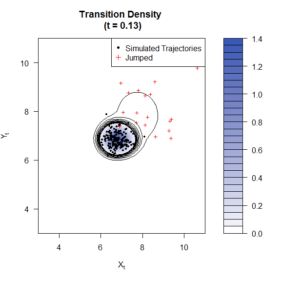

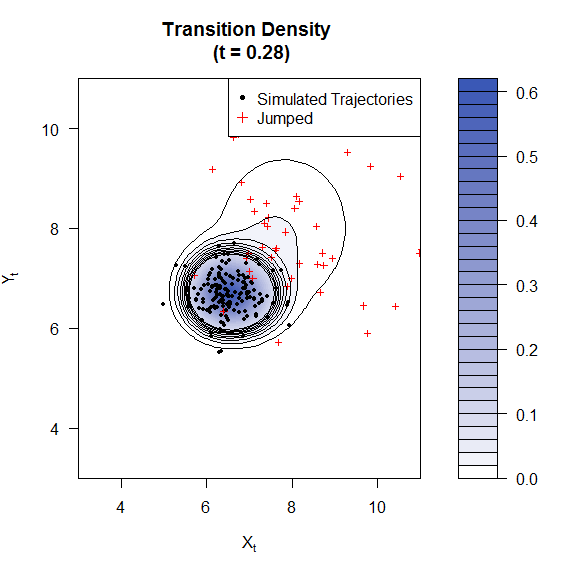

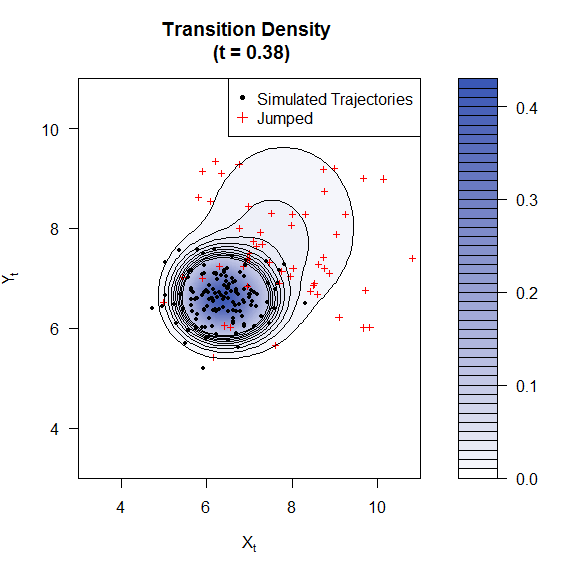

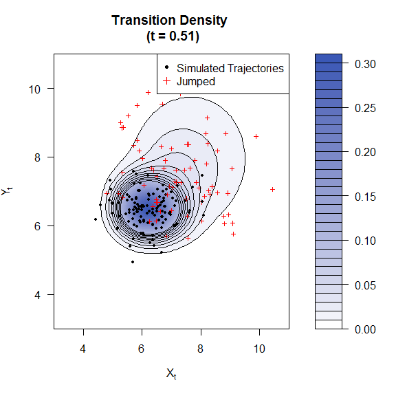

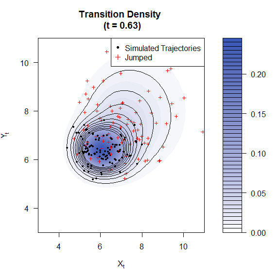

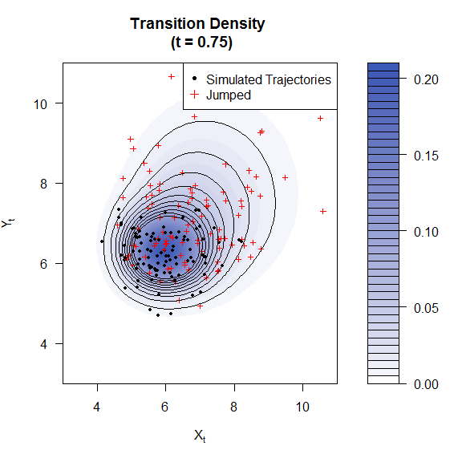

```r
 # Simulate the process
 mux     = function(x,y,t){a00(t)+a10(t)*x+a01(t)*y}
 sigmax  = function(x,y,t){sqrt(c10(t)*x)}
 muy     = function(x,y,t){b00(t)+b10(t)*x+b01(t)*y}
 sigmay  = function(x,y,t){sqrt(f01(t)*y)}
 lambda1 = function(x,y,t){Lam00(t)}
 lambda2 = function(x,y,t){rep(0,length(x))}

 j11     = function(x,y,z){z}
 j12     = function(x,y,z){z}
 j21     = function(x,y,z){z}
 j22     = function(x,y,z){z}
 simulate=function(x0=7,y0=7,N=10000,TT=5,delta=1/1000,pts,brks=30,plt=F)
 {
   library(colorspace)
   colpal=function(n){rev(sequential_hcl(n,power=0.8,l=c(40,100)))}

   d=0                  # Time index
   tt=seq(0,TT,delta)   # Time sequance
   X=rep(x0,N)          # Initialize state vectors
   Y=rep(y0,N)



   x.traj = rep(x0,length(tt))
   y.traj = rep(y0,length(tt))
   x.jump = rep(0,length(tt))
   y.jump = rep(0,length(tt))

   # Storage for histogram snapshots:
   count = 1
   L1=list()
   L2=list()
   evts = rep(0,N)
   for(i in 2:length(tt))
   {

    X=X+mux(X,Y,d)*delta+sigmax(X,Y,d)*rnorm(N,sd=sqrt(delta))
    Y=Y+muy(X,Y,d)*delta+sigmay(X,Y,d)*rnorm(N,sd=sqrt(delta))
    events1 = (lambda1(X,Y,d)*delta>runif(N))
    if(any(events1))
    {
      wh=which(events1)
      evts[wh]=evts[wh]+1
      X[wh]=X[wh]+j11(X[wh],Y[wh],rnorm(length(wh),Jmu1(d),sqrt(Jsig11(d))))
      Y[wh]=Y[wh]+j21(X[wh],Y[wh],rnorm(length(wh),Jmu2(d),sqrt(Jsig22(d))))
    }
    events2 = (lambda2(X,Y,d)*delta>runif(N))

    d=d+delta
   if(sum(round(pts,3)==round(d,3))!=0)
    {
    if(plt)
    {
     expr1 = expression(X_t)
     expr2 = expression(Y_t)
     color.palette=colorRampPalette(c('green','blue','red'))
     filled.contour(res$Xt,res$Yt,res$density[,,i],
                    main=paste0('Transition Density \n (t = ',round(d,2),')'),
                    color.palette=colpal,
                    nlevels=41,xlab=expression(X[t]),ylab=expression(Y[t]),plot.axes=
     {
        # Add simulated trajectories
        points(Y~X,pch=c(20,3)[(evts>0)+1],col=c('black','red')[(evts>0)+1],cex=c(0.9,0.6)[(evts>0)+1])
        if(any(events2))
        {
          wh=which(events2)
          segments(xpreee[wh],ypreee[wh],X[wh],Y[wh],col='gray')
        }
        axis(1);axis(2);
        # Add a legend
        legend('topright',col=c('black','red'),pch=c(20,3),
                legend=c('Simulated Trajectories','Jumped'))
        yy=contourLines(res$Xt,res$Yt,res$density[,,i],levels=seq(0.01,0.1,length=10))
        if(length(yy)>0)
        {
        for(j in 1:length(yy))
        {
         lines(yy[[j]])
        }
        }
     })
    }

       L1[[count]] = hist(X,plot=F,breaks=brks)
       L2[[count]] = hist(Y,plot=F,breaks=brks)
       count=count+1
       #savePlot(paste0('BiExampleTD',count,'.pdf'),type='pdf')
    }
  }
  return(list(time=tt,histsx=L1,histsy=L2,pts=pts))
}

sim=simulate(7,7,N=200,TT=0.75,delta=1/100,plt=T,pts=c(0.13,0.28,0.38,0.51,0.63,0.75))
```

# Comparison to existing methods

See also:

- Introduction

## Brownian motion with drift: Short transition horizon approximations (Section 4.1)

```r
rm(list=ls(all=TRUE))
#---------------------------------------------------------------------------
# Part 1: True density, series approximation and saddlepoint comparison
#---------------------------------------------------------------------------
library(DiffusionRjgqd)
JGQD.remove()
```

```
## [1] "Removed :  NA "
```

```
##
##  ================================================================
##             Jump Generalized Quadratic Diffusion (JGQD)
##  ================================================================
##  _____________________ Drift Coefficients _______________________
##  G0 : theta[1]
##  G1
##  G2
##  ___________________ Diffusion Coefficients _____________________
##  Q0 : theta[2]^2
##  Q1
##  Q2
##  _______________________ Jump Mechanism _________________________
##  ......................... Intensity ............................
##  Lam0 : theta[3]
##  Lam1
##  Lam2
##  ........................... Jumps ..............................
##  Normal
##  Jmu : theta[4]
##  Jsig : theta[5]
##  __________________ Distribution Approximant ____________________
##  Density approx. : Normal.A
##  Trunc. Order    : 8
##  Dens.  Order    : 4
## =================================================================
```

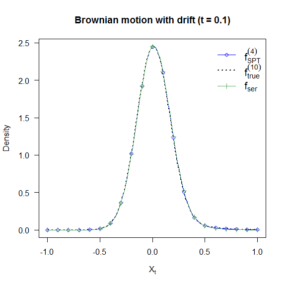

```
##
##  ================================================================
##             Jump Generalized Quadratic Diffusion (JGQD)
##  ================================================================
##  _____________________ Drift Coefficients _______________________
##  G0 : theta[1]
##  G1
##  G2
##  ___________________ Diffusion Coefficients _____________________
##  Q0 : theta[2]^2
##  Q1
##  Q2
##  _______________________ Jump Mechanism _________________________
##  ......................... Intensity ............................
##  Lam0 : theta[3]
##  Lam1
##  Lam2
##  ........................... Jumps ..............................
##  Normal
##  Jmu : theta[4]
##  Jsig : theta[5]
##  __________________ Distribution Approximant ____________________
##  Density approx. : Normal.A
##  Trunc. Order    : 8
##  Dens.  Order    : 4
## =================================================================
```

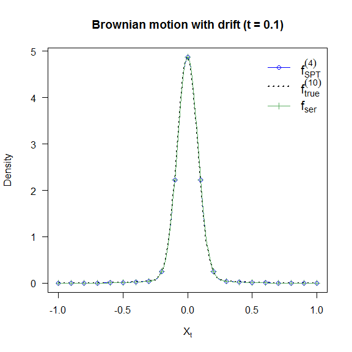

```
##
##  ================================================================
##             Jump Generalized Quadratic Diffusion (JGQD)
##  ================================================================
##  _____________________ Drift Coefficients _______________________
##  G0 : theta[1]
##  G1
##  G2
##  ___________________ Diffusion Coefficients _____________________
##  Q0 : theta[2]^2
##  Q1
##  Q2
##  _______________________ Jump Mechanism _________________________
##  ......................... Intensity ............................
##  Lam0 : theta[3]
##  Lam1
##  Lam2
##  ........................... Jumps ..............................
##  Normal
##  Jmu : theta[4]
##  Jsig : theta[5]
##  __________________ Distribution Approximant ____________________
##  Density approx. : Normal.A
##  Trunc. Order    : 8
##  Dens.  Order    : 4
## =================================================================
```

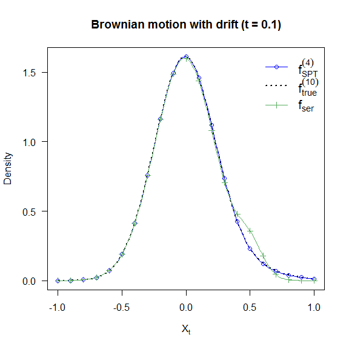

```r
theta1=c(0.1,0.5,0.5,0.2,0.25)
theta2=c(0.0,0.25,0.5,0.0,0.25)
theta3=c(-0.1,0.75,0.5,0.5,0.1)
pars =rbind(theta1,theta2,theta3)

# Define the jump diffusion using the DiffusionRjgqd syntax:
G0=function(t){theta[1]}
Q0=function(t){theta[2]^2}

# State dependent intensity:
Lam0 = function(t){theta[3]}
Jmu  = function(t){theta[4]}
Jsig = function(t){theta[5]}


 true.density=function(x,y,t,theta,order =1)
{
   mu   = theta[1]
   sig  = theta[2]
   lam  = theta[3]
   mu2  = theta[4]
   sig2 = theta[5]

   dens=exp(-lam*t)*dnorm(y,x+mu*t,sqrt(sig^2*t))
   for(i in 1:order)
   {
     dens= dens +exp(-lam*t)*(lam*t)^i/factorial(i)*dnorm(y,x+mu*t+i*mu2,sqrt(sig^2*t+i*sig2^2))
   }
   return(list(density=dens,Xt=y))
}

 herm.density=function(x,y,t,theta,type =1)
{
   mu  = theta[1]
   sig = theta[2]
   lam = theta[3]
   mu2 = theta[4]
   sig2 = theta[5]
   if(type == 1)
   {
     dens=1/sqrt(2*pi*sig^2*t)*exp(-(y-x)^2/(2*sig^2*t)+mu/sig^2*(y-x))*(1-(mu^2/(2*sig^2)+lam)*t)+lam*t/sqrt(2*pi*sig2^2)*exp(-(y-x-mu2)^2/(2*sig2^2))
   }

   if(type ==2)
   {
      dens=dnorm(y,x+mu*t,sqrt(sig^2*t))*(1-lam*t)+lam*t*dnorm(y,x+mu2,sqrt(sig2^2))
   }
   return(list(density=dens,Xt=y))
}

#================================ Short time =======================================
ind=10
for(i in 1:3)
{
 theta = pars[i,]
 res_1  = JGQD.density(0,seq(-1,1,1/100),0,1,1/100,factorize=T,Jdist='Normal',
                      Dtype='Normal.A')
 res_2 = true.density(0,res_1$Xt,ind*1/100,theta,order=10)
 res_3 = herm.density(0,res_1$Xt,ind*1/100,theta,type=1)

 expr1 = expression(f[SPT]^{(4)})
 expr2 = expression(f[true]^{(10)})
 expr3 = expression(f[ser])
 eprs =c(expr1,expr2,expr3)

 ltys = c('solid','dotted','solid')
 cols = c('blue' ,'black','#5AAE61')
 lwds = c(1,2,1)
 pchs=  c(1,NA,3)

 thin=seq(1,length(res_1$Xt),10)
 plot((res_2$density)~res_2$Xt,type='l',col=cols[2],lty=ltys[2],lwd=lwds[2],
 main=paste0('Brownian motion with drift (t = ',round(ind*1/100,2),')'),xlab=expression(X[t]),
 ylab='Density',las=1)

 lines((res_1$density[,ind])~res_1$Xt,col=cols[1],lty=ltys[1],lwd=lwds[1])
 points((res_1$density[thin,ind])~res_1$Xt[thin],col=cols[1],pch=pchs[1],cex=1)
 lines((res_3$density)~res_3$Xt,col=cols[3],lty=ltys[3],lwd=lwds[3])
points((res_3$density[thin])~res_3$Xt[thin],col=cols[3],pch=pchs[3],cex=0.9)
 legend('topright',legend=eprs,lty=ltys,lwd=lwds,col=cols,pch=pchs,bty='n',cex=1.25,pt.cex=1)

}
```

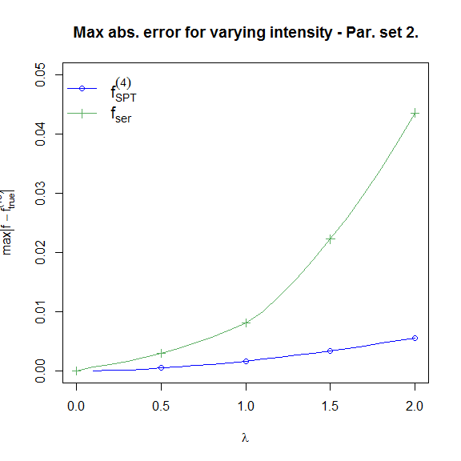

```r
#================================ Error at short ===========================
par(mfrow=c(1,1))
ind=10
lams= seq(0,2,1/10)
mxs1 = rep(0,length(lams))
mxs2 = rep(0,length(lams))
expr1 = expression(f[SPT]^{(4)})
expr2 = expression(f[ser])
eprs =c(expr1,expr2)

 ltys = c('solid','solid')
 cols = c('blue' ,'#5AAE61')
 lwds = c(1,1)
 pchs=  c(1,3)
plot(mxs1~lams,type='n',ylim=c(0,0.05),xlab=expression(lambda),ylab=expression(max(abs(hat(f)-f[true]^{(10)}))),main='Max abs. error for varying intensity - Par. set 2.')
for(j in 2){
for(i in 1:length(lams))
{
  theta = pars[j,]
  theta[3] = lams[i]
  res_1  = JGQD.density(0,seq(-1.5,1.5,1/100),0,0.25,1/100,factorize=T,Jdist='Normal',
                      Dtype='Normal.A',print.output=FALSE)
  res_5 = true.density(0,res_1$Xt,ind*1/100,theta,order=10)
  res_2 = herm.density(0,res_1$Xt,ind*1/100,theta,type=1)
  mxs1[i] = max(abs(res_5$density-res_1$density[,ind]))
  mxs2[i] = max(abs(res_5$density-res_2$density))


}
sq=seq(1,length(lams),5)
lines(mxs1~lams,col=cols[1],lwd=lwds[1],lty=ltys[1],pch=pchs[1])
points(mxs1[sq]~lams[sq],col=cols[1],lwd=lwds[1],lty=ltys[1],pch=pchs[1])
lines(mxs2~lams,col=cols[2],lwd=lwds[2],lty=ltys[2])
points(mxs2[sq]~lams[sq],col=cols[2],lwd=lwds[2],lty=ltys[2],pch=pchs[2])

}
legend('topleft',legend=eprs,lty=c(ltys),lwd=c(lwds,1,1,1),
       col=c(cols),bty='n',cex=1.25,pt.cex=1,pch=pchs)
```

```r
#---------------------------------------------------------------------------
# Part 2: Simulated, convolution, series approximation and saddlepoint
#         comparison for Exponential and Laplace jumps
#---------------------------------------------------------------------------
rm(list=ls(all=TRUE))
library(DiffusionRjgqd)
JGQD.remove()
```

```
## [1] "Removed :  NA "
```

```
##
##  ================================================================
##             Jump Generalized Quadratic Diffusion (JGQD)
##  ================================================================
##  _____________________ Drift Coefficients _______________________
##  G0 : theta[1]
##  G1
##  G2
##  ___________________ Diffusion Coefficients _____________________
##  Q0 : theta[2]^2
##  Q1
##  Q2
##  _______________________ Jump Mechanism _________________________
##  ......................... Intensity ............................
##  Lam0 : theta[3]
##  Lam1
##  Lam2
##  ........................... Jumps ..............................
##  Exponential
##  Jlam : 1/theta[4]
##  __________________ Distribution Approximant ____________________
##  Density approx. : Normal.A
##  Trunc. Order    : 8
##  Dens.  Order    : 4
## =================================================================
```

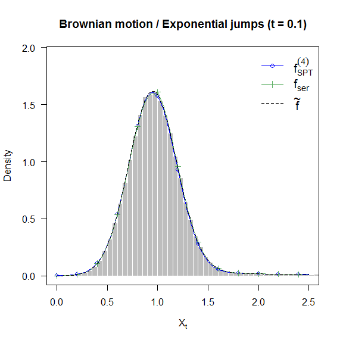

```
##
##  ================================================================
##             Jump Generalized Quadratic Diffusion (JGQD)
##  ================================================================
##  _____________________ Drift Coefficients _______________________
##  G0 : theta[1]
##  G1
##  G2
##  ___________________ Diffusion Coefficients _____________________
##  Q0 : theta[2]^2
##  Q1
##  Q2
##  _______________________ Jump Mechanism _________________________
##  ......................... Intensity ............................
##  Lam0 : theta[3]
##  Lam1
##  Lam2
##  ........................... Jumps ..............................
##  Exponential
##  Jlam : 1/theta[4]
##  __________________ Distribution Approximant ____________________
##  Density approx. : Normal.A
##  Trunc. Order    : 8
##  Dens.  Order    : 4
## =================================================================
```

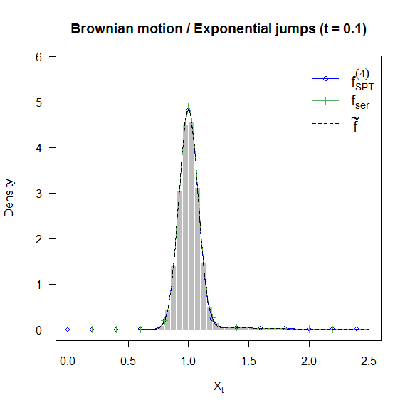

```
##
##  ================================================================
##             Jump Generalized Quadratic Diffusion (JGQD)
##  ================================================================
##  _____________________ Drift Coefficients _______________________
##  G0 : theta[1]
##  G1
##  G2
##  ___________________ Diffusion Coefficients _____________________
##  Q0 : theta[2]^2
##  Q1
##  Q2
##  _______________________ Jump Mechanism _________________________
##  ......................... Intensity ............................
##  Lam0 : theta[3]
##  Lam1
##  Lam2
##  ........................... Jumps ..............................
##  Exponential
##  Jlam : 1/theta[4]
##  __________________ Distribution Approximant ____________________
##  Density approx. : Normal.A
##  Trunc. Order    : 8
##  Dens.  Order    : 4
## =================================================================
```

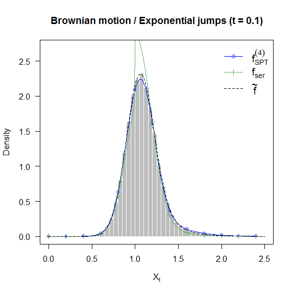

```
##
##  ================================================================
##             Jump Generalized Quadratic Diffusion (JGQD)
##  ================================================================
##  _____________________ Drift Coefficients _______________________
##  G0 : theta[1]
##  G1
##  G2
##  ___________________ Diffusion Coefficients _____________________
##  Q0 : theta[2]^2
##  Q1
##  Q2
##  _______________________ Jump Mechanism _________________________
##  ......................... Intensity ............................
##  Lam0 : theta[3]
##  Lam1
##  Lam2
##  ........................... Jumps ..............................
##  Exponential
##  Jlam : 1/theta[4]
##  __________________ Distribution Approximant ____________________
##  Density approx. : Normal.A
##  Trunc. Order    : 8
##  Dens.  Order    : 4
## =================================================================
```

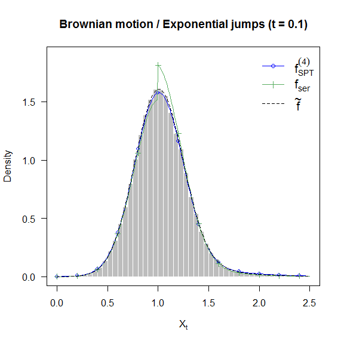

```r
Xs = 1
tau = 0.1
theta1=c(-0.5,0.75,0.5,1);
theta2=c(0,0.25 ,0.5,2);
theta3=c(0.5,0.5,2,5);
theta4=c(0,0.75,1,3);
pars =rbind(theta1,theta2,theta3,theta4)

# Define the jump diffusion using the DiffusionRjgqd syntax:
G0=function(t){theta[1]}
Q0=function(t){theta[2]^2}

# State dependent intensity:
Lam0 = function(t){theta[3]}
Jlam  = function(t){1/theta[4]}

  sim=function(tau,theta)
 {
  N= 100000
  X=rep(Xs,N)
  dt=1/2000
  tt = seq(0,tau,dt)
  for(i in 2:length(tt))
  {
    X = X +theta[1]*dt+theta[2]*rnorm(N,0,sqrt(dt))
    events = (theta[3]*dt>runif(N))
    if(any(events))
    {
      wh=which(events)
      X[wh]=X[wh]+rexp(length(wh),theta[4])
    }
  }
  return(list(X=X))
 }
herm.density=function(x,y,t,theta,type =1)
{
   mu  = theta[1]
   sig = theta[2]
   lam = theta[3]
   lam.z = theta[4]
   if(type == 1)
   {
     dens=1/sqrt(2*pi*sig^2*t)*exp(-(y-x)^2/(2*sig^2*t)+mu/sig^2*(y-x))*(1-(mu^2/(2*sig^2)+lam)*t)+lam*t*dexp(y-x,lam.z)
   }

   if(type ==2)
   {
      dens=dnorm(y,x+mu*t,sqrt(sig^2*t))*(1-lam*t)+lam*t*dexp(y-x,lam.z)
   }
   return(list(density=dens,Xt=y))
}

 conv.density=function(x,y,t,theta)
{
   mu  = theta[1]
   sig = theta[2]
   lam = theta[3]
   lam.z = theta[4]
   dens = dnorm(y,x+mu*t,sqrt(sig^2*t))*(1-lam*t)+lam*t*lam.z*exp((y-x-mu*t-lam.z*sig^2*t)^2/(2*sig^2*t)-(y-x-mu*t)^2/(2*sig^2*t))*(1-pnorm(0,y-x-mu*t-lam.z*sig^2*t,sqrt(sig^2*t)))
   return(list(density=dens,Xt=y))
}
 for(i in 1:4)
{
theta=pars[i,]
res_1  = JGQD.density(Xs,seq(0,2.5,1/100),0,1,1/100,factorize=T,Jdist='Exponential',
                      Dtype='Normal.A')
res_2 = herm.density(Xs,res_1$Xt,tau,theta,type=1)
res_3 = conv.density(Xs,res_1$Xt,tau,theta)
res.sim = sim(tau,theta)

expr1 = expression(f[SPT]^{(4)})
expr2 = expression(f[ser])
expr3 = expression(tilde(f))
eprs =c(expr1,expr2,expr3)

ltys = c('solid','solid','dashed')
cols = c('blue','#5AAE61','black')
lwds = c(1,1,1)
pchs=  c(1,3,NA)

thin=seq(1,length(res_1$Xt),20)
hist(res.sim$X,freq=FALSE,border='white',main=paste0('Brownian motion / Exponential jumps (t = ',tau,')'),
  breaks=seq(-25,25,1/20),xlab=expression(X[t]),ylab='Density',las=1,xlim=range(res_1$Xt),ylim=c(0,max(res_1$density[,tau*100])*1.2),,col='gray74')
lines((res_1$density[,tau*100])~res_1$Xt,type='l',col=cols[1],lty=ltys[1],lwd=lwds[1])
points((res_1$density[thin,tau*100])~res_1$Xt[thin],col=cols[1],pch=pchs[1],cex=0.9)
lines((res_2$density)~res_2$Xt,col=cols[2],lty=ltys[2],lwd=lwds[2])
points((res_2$density[thin])~res_2$Xt[thin],col=cols[2],pch=pchs[2],cex=0.9)
lines((res_3$density)~res_3$Xt,col=cols[3],lty=ltys[3],lwd=lwds[3])

legend('topright',legend=eprs,lty=ltys,lwd=lwds,col=cols,pch=pchs,bty='n',cex=1.25,pt.cex=1)
box()
}
```

```r
rm(list=ls(all=TRUE))
library("smoothmest")
JGQD.remove()
```

```
## [1] "Removed :  NA "
```

```
##
##  ================================================================
##             Jump Generalized Quadratic Diffusion (JGQD)
##  ================================================================
##  _____________________ Drift Coefficients _______________________
##  G0 : theta[1]
##  G1
##  G2
##  ___________________ Diffusion Coefficients _____________________
##  Q0 : theta[2]^2
##  Q1
##  Q2
##  _______________________ Jump Mechanism _________________________
##  ......................... Intensity ............................
##  Lam0 : theta[3]
##  Lam1
##  Lam2
##  ........................... Jumps ..............................
##  Laplace
##  Ja : theta[4]
##  Jb : theta[5]
##  __________________ Distribution Approximant ____________________
##  Density approx. : Normal.A
##  Trunc. Order    : 8
##  Dens.  Order    : 4
## =================================================================
```

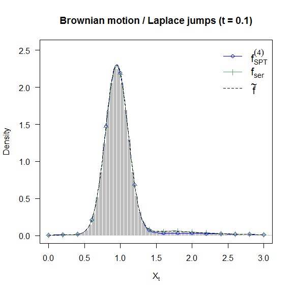

```
##
##  ================================================================
##             Jump Generalized Quadratic Diffusion (JGQD)
##  ================================================================
##  _____________________ Drift Coefficients _______________________
##  G0 : theta[1]
##  G1
##  G2
##  ___________________ Diffusion Coefficients _____________________
##  Q0 : theta[2]^2
##  Q1
##  Q2
##  _______________________ Jump Mechanism _________________________
##  ......................... Intensity ............................
##  Lam0 : theta[3]
##  Lam1
##  Lam2
##  ........................... Jumps ..............................
##  Laplace
##  Ja : theta[4]
##  Jb : theta[5]
##  __________________ Distribution Approximant ____________________
##  Density approx. : Normal.A
##  Trunc. Order    : 8
##  Dens.  Order    : 4
## =================================================================
```

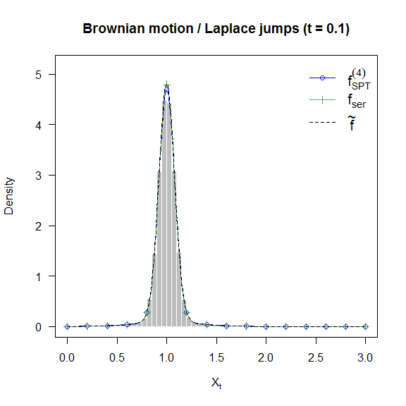

```
##
##  ================================================================
##             Jump Generalized Quadratic Diffusion (JGQD)
##  ================================================================
##  _____________________ Drift Coefficients _______________________
##  G0 : theta[1]
##  G1
##  G2
##  ___________________ Diffusion Coefficients _____________________
##  Q0 : theta[2]^2
##  Q1
##  Q2
##  _______________________ Jump Mechanism _________________________
##  ......................... Intensity ............................
##  Lam0 : theta[3]
##  Lam1
##  Lam2
##  ........................... Jumps ..............................
##  Laplace
##  Ja : theta[4]
##  Jb : theta[5]
##  __________________ Distribution Approximant ____________________
##  Density approx. : Normal.A
##  Trunc. Order    : 8
##  Dens.  Order    : 4
## =================================================================
```

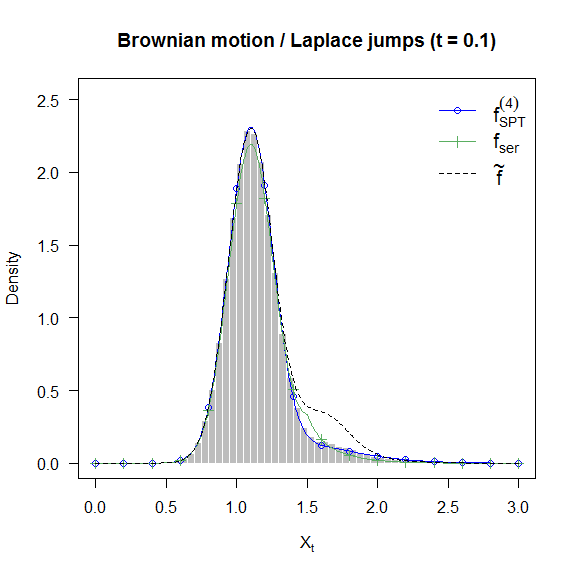

```
##
##  ================================================================
##             Jump Generalized Quadratic Diffusion (JGQD)
##  ================================================================
##  _____________________ Drift Coefficients _______________________
##  G0 : theta[1]
##  G1
##  G2
##  ___________________ Diffusion Coefficients _____________________
##  Q0 : theta[2]^2
##  Q1
##  Q2
##  _______________________ Jump Mechanism _________________________
##  ......................... Intensity ............................
##  Lam0 : theta[3]
##  Lam1
##  Lam2
##  ........................... Jumps ..............................
##  Laplace
##  Ja : theta[4]
##  Jb : theta[5]
##  __________________ Distribution Approximant ____________________
##  Density approx. : Normal.A
##  Trunc. Order    : 8
##  Dens.  Order    : 4
## =================================================================
```

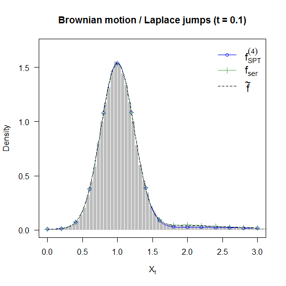

```r
Xs = 1
tau = 0.1
theta1=c(-0.5,0.5 ,1,0.75,0.75);
theta2=c(0,0.25,1,0,0.2);
theta3=c(1.0 ,0.5 ,1,0.5,0.2);
theta4=c(0 ,0.75,1,1,1);
pars =rbind(theta1,theta2,theta3,theta4)

# Define the jump diffusion using the DiffusionRjgqd syntax:
G0=function(t){theta[1]}
Q0=function(t){theta[2]^2}

# State dependent intensity:
Lam0  = function(t){theta[3]}
Ja  = function(t){theta[4]}
Jb  = function(t){theta[5]}


 sim=function(tau,theta)
 {
  N= 100000
  X=rep(Xs,N)
  dt=1/2000
  tt = seq(0,tau,dt)
  for(i in 2:length(tt))
  {
    X = X +theta[1]*dt+theta[2]*rnorm(N,0,sqrt(dt))
    events = (1-exp(-theta[3]*dt)>runif(N))
    if(any(events))
    {
      wh=which(events)
      X[wh]=X[wh]+rdoublex(length(wh),theta[4],theta[5])
    }
  }
  return(list(X=X))
 }
 herm.density=function(x,y,t,theta,type =1)
{
   mu  = theta[1]
   sig = theta[2]
   lam = theta[3]
   mu.z = theta[4]
   b.z = theta[5]
   if(type == 1)
   {
     dens=1/sqrt(2*pi*sig^2*t)*exp(-(y-x)^2/(2*sig^2*t)+mu/sig^2*(y-x))*(1-(mu^2/(2*sig^2)+lam)*t)+lam*t*ddoublex(y-x,mu.z,b.z)
   }

   if(type ==2)
   {
      dens=dnorm(y,x+mu*t,sqrt(sig^2*t))*(1-lam*t)+lam*t*ddoublex(y-x,mu.z,b.z)
   }
   return(list(density=dens,Xt=y))
}

 conv.density=function(x,y,t,theta)
{
   mu  = theta[1]
   sig = theta[2]
   lam = theta[3]
   mu.z = theta[4]
   b.z = theta[5]
   term1 = dnorm(y,x+mu*t,sqrt(sig^2*t))*(1-lam*t)
   term2 =  lam*t/(2*b.z)*exp((y-x-mu*t-b.z^-1*sig^2*t)^2/(2*sig^2*t)-(y-x-mu*t)^2/(2*sig^2*t)+mu.z/b.z)*(1-pnorm(mu.z,(y-x-mu*t-b.z^2*sig^2*t),sqrt(sig^2*t),lower.tail=T))
   term3 =  lam*t/(2*b.z)*exp((y-x-mu*t+b.z^-1*sig^2*t)^2/(2*sig^2*t)-(y-x-mu*t)^2/(2*sig^2*t)-mu.z/b.z)*pnorm(mu.z,(y-x-mu*t+b.z^2*sig^2*t),sqrt(sig^2*t),lower.tail=T)
   return(list(density=term1+term2+term3,Xt=y))
}

 for(i in 1:4)
{
theta=pars[i,]
res_1 = JGQD.density(Xs,seq(0,3,1/100),0,1,1/100,factorize=T,Jdist='Laplace',
                      Dtype='Normal.A')
res_2 = herm.density(Xs,res_1$Xt,tau,theta,type=1)
res_3 = conv.density(Xs,res_1$Xt,tau,theta)
res.sim = sim(tau,theta)

expr1 = expression(f[SPT]^{(4)})
expr2 = expression(f[ser])
expr3 = expression(tilde(f))
eprs =c(expr1,expr2,expr3)

ltys = c('solid','solid','dashed')
cols = c('blue','#5AAE61','black')
lwds = c(1,1,1)
pchs=  c(1,3,NA)

thin=seq(1,length(res_1$Xt),20)
hist(res.sim$X,freq=FALSE,border='white',main=paste0('Brownian motion / Laplace jumps (t = ',tau,')'),
  breaks=seq(-15,15,1/20),xlab=expression(X[t]),ylab='Density',las=1,xlim=range(res_1$Xt),ylim=c(0,max(res_1$density[,tau*100])*1.1),col='gray74')

lines((res_1$density[,tau*100])~res_1$Xt,type='l',col=cols[1],lty=ltys[1],lwd=lwds[1])
points((res_1$density[thin,tau*100])~res_1$Xt[thin],col=cols[1],pch=pchs[1],cex=1,lwd=lwds[1])
lines((res_2$density)~res_2$Xt,col=cols[2],lty=ltys[2],lwd=lwds[2])
points((res_2$density[thin])~res_2$Xt[thin],col=cols[2],pch=pchs[2],cex=1,lwd=lwds[2])
lines((res_3$density)~res_3$Xt,col=cols[3],lty=ltys[3],lwd=lwds[3])

legend('topright',legend=eprs,lty=ltys,lwd=lwds,col=cols,pch=pchs,bty='n',cex=1.25,pt.cex=1)
box()

}
```

## State dependent models: Characteristic equations (Section 4.2)

Note: the `characteristic_function_to_density ()` was adapted from an excellent post by [Vincent Zoonekynd](http://stackoverflow.com/users/1129973/vincent-zoonekynd).

```r
rm(list=ls(all=TRUE))
#=========================================================
# Part 1: BAJD
# Evaluate the transition density at time tau =0.25 using
# the characteristic function
#=========================================================
 library(DiffusionRjgqd)
 # Some peripheral parameters:
 theta1 = c(1   ,5   ,0.5   ,3 ,0.5  ); xlim1 =c(3,6)
 theta2 = c(0.5 ,5   ,0.25  ,5 ,1  )  ; xlim2 =c(3,6)
 theta3 = c(1   ,5   ,0.5   ,4 ,1.5)  ; xlim3 =c(3,6)
 theta4 = c(0.75,5   ,0.25  ,6 ,3  ) ; xlim4 =c(2,9)
 pars   = rbind(theta1,theta2,theta3,theta4)
 xs     = rbind(xlim1,xlim2,xlim3,xlim4)
 taus   = c(0.1,0.2,0.25,5)

 x0  = 4

  sim=function(tau,theta)
 {
  N= 25000
  X=rep(x0,N)
  dt=1/2000
  tt = seq(0,tau,dt)
  for(i in 2:length(tt))
  {
    X = X +theta[1]*(theta[2]-X)*dt+theta[3]*sqrt(X)*rnorm(N,0,sqrt(dt))
    events = (1-exp(-theta[5]*dt)>runif(N))
    if(any(events))
    {
      wh=which(events)
      X[wh]=X[wh]+rexp(length(wh),theta[4])
    }
  }
  return(list(X=X))
 }

# From CF to the appr. density:
characteristic_function_to_density = function(phi,n,a,b)
{
  i  = 0:(n-1)
  dx = (b-a)/n
  x  = seq(a,b-dx,length =n)
  dt = 2*pi / ( n * dx )
  c  = -n/2 * dt
  d  =  n/2 * dt
  t  = c + i * dt

  phi_t = phi(t)
  X = exp(-(0+1i)*i*dt*a)*phi_t
  Y = fft(X)
  density = dt /(2*pi)*exp(-(0+1i)*c*x)*Y
  list(x = x,density = Re(density))

}

# The characteristic function:
f =function(t,theta =th)
{
 a     = theta[1]
 b     = theta[2]
 sigma = theta[3]
 nu    = theta[4]
 cc    = theta[5]
 u=(0+1i)*t
 term1 = (1-(sigma^2*u)/(2*a)*(1-exp(-a*tau)))^(-2*a*b/sigma^2)
 term2 = ((nu*(1-sigma^2*u/(2*a))-(1-sigma^2*nu/(2*a))*u*exp(-a*tau))/(nu-u))^(cc/(a-sigma^2*nu/2))
 term3 =  exp(x0*u*exp(-a*tau)/(1-sigma^2/(2*a)*u*(1-exp(-a*tau))))
 rs=term1*term2*term3
 return(rs)
}



JGQD.remove()
```

```
## [1] "Removed :  NA "
```

```
##
##  ================================================================
##             Jump Generalized Quadratic Diffusion (JGQD)
##  ================================================================
##  _____________________ Drift Coefficients _______________________
##  G0 : th[1]*th[2]
##  G1 : -th[1]
##  G2
##  ___________________ Diffusion Coefficients _____________________
##  Q0
##  Q1 : th[3]^2
##  Q2
##  _______________________ Jump Mechanism _________________________
##  ......................... Intensity ............................
##  Lam0 : th[5]
##  Lam1
##  Lam2
##  ........................... Jumps ..............................
##  Exponential
##  Jlam : 1/th[4]
##  __________________ Distribution Approximant ____________________
##  Density approx. : Saddlepoint
##  Trunc. Order    : 8
##  Dens.  Order    : 4
## =================================================================
##
##  ================================================================
##             Jump Generalized Quadratic Diffusion (JGQD)
##  ================================================================
##  _____________________ Drift Coefficients _______________________
##  G0 : th[1]*th[2]
##  G1 : -th[1]
##  G2
##  ___________________ Diffusion Coefficients _____________________
##  Q0
##  Q1 : th[3]^2
##  Q2
##  _______________________ Jump Mechanism _________________________
##  ......................... Intensity ............................
##  Lam0 : th[5]
##  Lam1
##  Lam2
##  ........................... Jumps ..............................
##  Exponential
##  Jlam : 1/th[4]
##  __________________ Distribution Approximant ____________________
##  Density approx. : Saddlepoint
##  Trunc. Order    : 8
##  Dens.  Order    : 4
## =================================================================
```

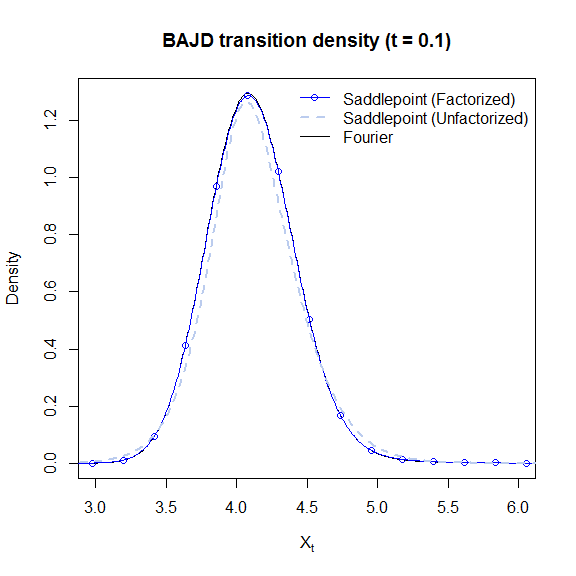

```
##
##  ================================================================
##             Jump Generalized Quadratic Diffusion (JGQD)
##  ================================================================
##  _____________________ Drift Coefficients _______________________
##  G0 : th[1]*th[2]
##  G1 : -th[1]
##  G2
##  ___________________ Diffusion Coefficients _____________________
##  Q0
##  Q1 : th[3]^2
##  Q2
##  _______________________ Jump Mechanism _________________________
##  ......................... Intensity ............................
##  Lam0 : th[5]
##  Lam1
##  Lam2
##  ........................... Jumps ..............................
##  Exponential
##  Jlam : 1/th[4]
##  __________________ Distribution Approximant ____________________
##  Density approx. : Saddlepoint
##  Trunc. Order    : 8
##  Dens.  Order    : 4
## =================================================================
##
##  ================================================================
##             Jump Generalized Quadratic Diffusion (JGQD)
##  ================================================================
##  _____________________ Drift Coefficients _______________________
##  G0 : th[1]*th[2]
##  G1 : -th[1]
##  G2
##  ___________________ Diffusion Coefficients _____________________
##  Q0
##  Q1 : th[3]^2
##  Q2
##  _______________________ Jump Mechanism _________________________
##  ......................... Intensity ............................
##  Lam0 : th[5]
##  Lam1
##  Lam2
##  ........................... Jumps ..............................
##  Exponential
##  Jlam : 1/th[4]
##  __________________ Distribution Approximant ____________________
##  Density approx. : Saddlepoint
##  Trunc. Order    : 8
##  Dens.  Order    : 4
## =================================================================
```

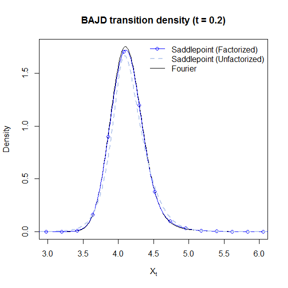

```
##
##  ================================================================
##             Jump Generalized Quadratic Diffusion (JGQD)
##  ================================================================
##  _____________________ Drift Coefficients _______________________
##  G0 : th[1]*th[2]
##  G1 : -th[1]
##  G2
##  ___________________ Diffusion Coefficients _____________________
##  Q0
##  Q1 : th[3]^2
##  Q2
##  _______________________ Jump Mechanism _________________________
##  ......................... Intensity ............................
##  Lam0 : th[5]
##  Lam1
##  Lam2
##  ........................... Jumps ..............................
##  Exponential
##  Jlam : 1/th[4]
##  __________________ Distribution Approximant ____________________
##  Density approx. : Saddlepoint
##  Trunc. Order    : 8
##  Dens.  Order    : 4
## =================================================================
##
##  ================================================================
##             Jump Generalized Quadratic Diffusion (JGQD)
##  ================================================================
##  _____________________ Drift Coefficients _______________________
##  G0 : th[1]*th[2]
##  G1 : -th[1]
##  G2
##  ___________________ Diffusion Coefficients _____________________
##  Q0
##  Q1 : th[3]^2
##  Q2
##  _______________________ Jump Mechanism _________________________
##  ......................... Intensity ............................
##  Lam0 : th[5]
##  Lam1
##  Lam2
##  ........................... Jumps ..............................
##  Exponential
##  Jlam : 1/th[4]
##  __________________ Distribution Approximant ____________________
##  Density approx. : Saddlepoint
##  Trunc. Order    : 8
##  Dens.  Order    : 4
## =================================================================
```

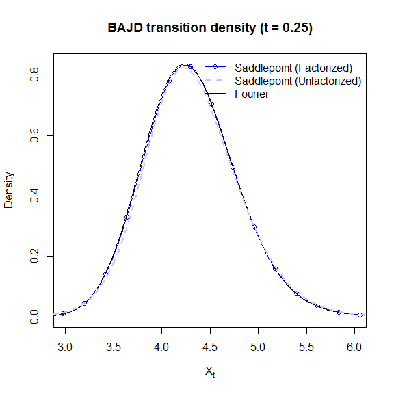

```
##
##  ================================================================
##             Jump Generalized Quadratic Diffusion (JGQD)
##  ================================================================
##  _____________________ Drift Coefficients _______________________
##  G0 : th[1]*th[2]
##  G1 : -th[1]
##  G2
##  ___________________ Diffusion Coefficients _____________________
##  Q0
##  Q1 : th[3]^2
##  Q2
##  _______________________ Jump Mechanism _________________________
##  ......................... Intensity ............................
##  Lam0 : th[5]
##  Lam1
##  Lam2
##  ........................... Jumps ..............................
##  Exponential
##  Jlam : 1/th[4]
##  __________________ Distribution Approximant ____________________
##  Density approx. : Saddlepoint
##  Trunc. Order    : 8
##  Dens.  Order    : 4
## =================================================================
##
##  ================================================================
##             Jump Generalized Quadratic Diffusion (JGQD)
##  ================================================================
##  _____________________ Drift Coefficients _______________________
##  G0 : th[1]*th[2]
##  G1 : -th[1]
##  G2
##  ___________________ Diffusion Coefficients _____________________
##  Q0
##  Q1 : th[3]^2
##  Q2
##  _______________________ Jump Mechanism _________________________
##  ......................... Intensity ............................
##  Lam0 : th[5]
##  Lam1
##  Lam2
##  ........................... Jumps ..............................
##  Exponential
##  Jlam : 1/th[4]
##  __________________ Distribution Approximant ____________________
##  Density approx. : Saddlepoint
##  Trunc. Order    : 8
##  Dens.  Order    : 4
## =================================================================
```

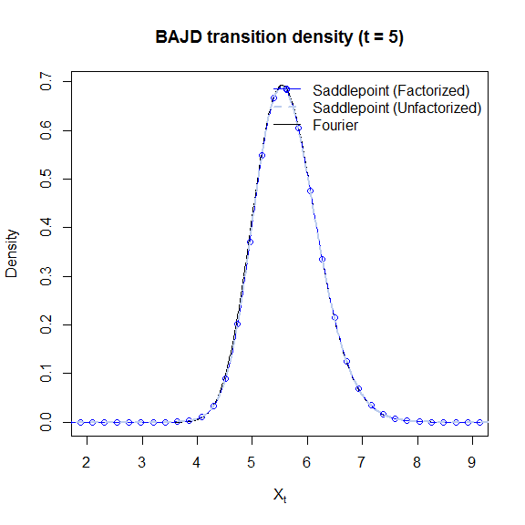

```r
G0=function(t){th[1]*th[2]}
G1=function(t){-th[1]}
Q1=function(t){th[3]^2}
Lam0 =function(t){th[5]}
Jlam =function(t){1/th[4]}

for(i in 1:4)
{
 th = pars[i,]
 tau =taus[i]

 #res.sim = sim(tau,th)
 d <-characteristic_function_to_density(f,2^10,1,10)
 res_1=JGQD.density(4,d$x,0,tau,delt=1/100,Jdist='Exponential',factorize=TRUE)#,Dtype='Gamma.Saddle')
 res_2=JGQD.density(4,d$x,0,tau,delt=1/100,Jdist='Exponential',factorize=FALSE)#,Dtype='Gamma.Saddle')

 xlims= xs[i,]
 ylims= c(0,2.8)
 cols= c('blue','#BBCCEE','black')
 ltys= c('solid','dashed','solid')
 lwds = c(1,2,1)
 pchs=  c(1,NA,NA)
 thin=seq(1,length(res_1$Xt),25)
 eprs =c('Saddlepoint (Factorized)',
 'Saddlepoint (Unfactorized)',
 'Fourier')

 #hist(res.sim$X,breaks=seq(0,25,1/10),freq=F,border='white',col='white',
 plot(d$x,(d$density),type='n',axes=T  ,col=cols[1],lty=ltys[1],lwd=lwds[1],
      xlim=xlims, ylab='Density',xlab=expression(X[t]),
      main=paste0('BAJD transition density (t = ',tau,')'))
 lines(d$density~d$x    ,col=cols[3],lty=ltys[3],lwd=lwds[3])
 lines(res_1$density[,100*tau]~res_1$Xt    ,col=cols[1],lty=ltys[1],lwd=lwds[1])
 points(res_1$density[thin,100*tau]~res_1$Xt[thin],col=cols[1],pch=pchs[1])
 lines (res_2$density[,100*tau]~res_2$Xt,col=cols[2],lty=ltys[2],lwd=lwds[2])
 points(res_2$density[thin,100*tau]~res_2$Xt[thin],col=cols[2],pch=pchs[2])

 legend('topright',legend=eprs,lty=ltys,lwd=lwds,col=cols,pch=pchs,bty='n')

}
```